# INF-350 INTELIGENCIA ARTIFICIAL

### Ing. Francisco Suárez

# Herramientas

1. Python (Anaconda)
2. Jupyter Notebook
3. Github (https://github.com/fjsuarez/UCB_demo)

# Texto

Russell & Norvig, AI: A Modern Approach, 3rd Ed.

[figure not shown]

# k-means clustering

k-means clustering particiona n observaciones en k clusers en la que cada observación pertenece al cluster con la media (mean) más cercana.

Aquí implementamos un algoritmo heurístico para k-means clustering.

Tenemos N puntos que queremos particionar en K clusters.

Funciona de la siguiente manera:

### Paso 1: Inicializar clusters

1. Elegir K puntos aleatorios de N puntos.
2. Asiganar cada uno de los otros N-K puntos a un cluster $ C_i $ donde "i" es el índice del punto más cercano de los K puntos previamente seleccionados.

### Paso 2: Iterar cambiando los clusters hasta encontrar convergencia

Repetir hasta que no hayan cambios:

1. Para cada cluster, computar la media.
2. Iterar en todos los N puntos y asignarlos a un cluster indexado por la media más cercana.

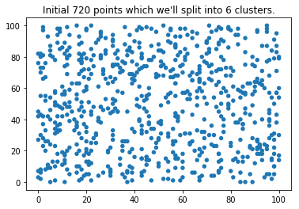

```python
# Number of points.
N = 720

# Number of clusters.
K = 6

points = []
for i in range(0, N):
  x = random.randint(0, 100)
  y = random.randint(0, 100)
  points.append((x, y))

plot_points('Initial %d points which we\'ll split into %d clusters.' % (N, K), use_colors=False)
```

```python
cluster = [-1] * N

indices = list(range(0, N))
random.shuffle(indices)

mean_point_idxs = indices[0: K]

for i in range(0, K):
  cluster[ mean_point_idxs[i] ] = i

for idx in range(0, N):
  if idx not in mean_point_idxs:
    # Find closest.
    ci = -1
    mindistance = 1 << 30
    for i in range(0, K):
      cm = mean_point_idxs[i]
      distance = (points[idx][0] - points[cm][0]) ** 2 + (points[idx][1] - points[cm][1]) ** 2
      if distance < mindistance:
        mindistance = distance
        ci = i

    cluster[idx] = ci
```

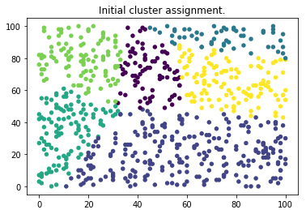

```python
plot_points('Initial cluster assignment.')
```

```python
for iter in range(0, 50):
  # Compute mean for every cluster.
  sumx = [0.0] * K
  sumy = [0.0] * K
  totals = [0] * K
  for i in range(0, N):
    sumx[ cluster[i] ] += points[i][0]
    sumy[ cluster[i] ] += points[i][1]
    totals[ cluster[i] ] += 1
```

```python
  # Compute new means.
  meanx = [0] * K
  meany = [0] * K
  for i in range(0, K):
    meanx[i] = sumx[i] / totals[i]
    meany[i] = sumy[i] / totals[i]
```

```python
  # Create new clusters.
  new_cluster = [0] * N
  for i in range(0, N):
    mindist = 1 << 30
    for j in range(0, K):
      dist = (points[i][0] - meanx[j]) ** 2 + (points[i][1] - meany[j]) ** 2
      if dist < mindist:
        mindist = dist
        cluster_idx = j

    new_cluster[i] = cluster_idx

  if cluster == new_cluster:
    print('DONE')
    break
  else:
    moved = 0
    for i in range(0, N):
      if cluster[i] != new_cluster[i]: moved += 1
    print ('MOVED =', moved)

    cluster = new_cluster
```

```
MOVED = 49
```

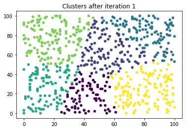

```
MOVED = 28
```

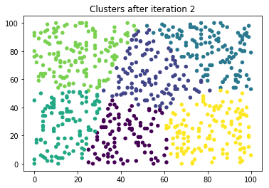

```
MOVED = 16
```

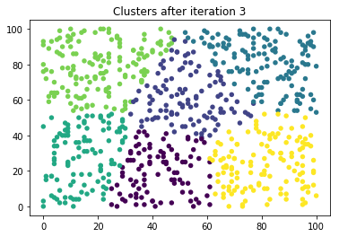

```
MOVED = 12
```

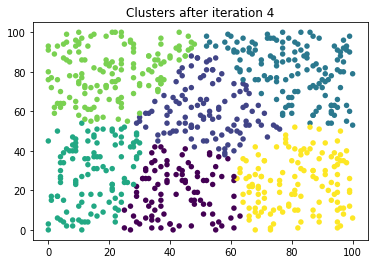

```
MOVED = 8
```

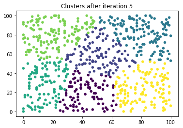

```
MOVED = 8
```

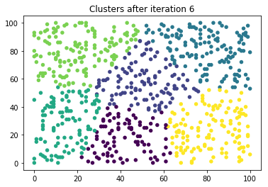

```
MOVED = 10
```

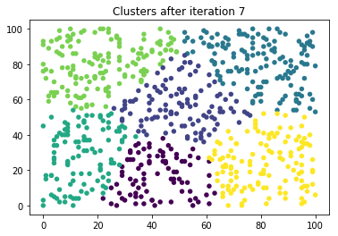

```
MOVED = 9
```

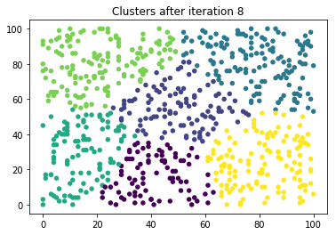

```
MOVED = 7
```

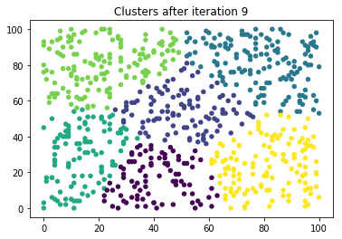

```
MOVED = 3
```

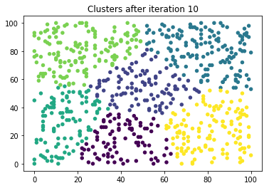

```
DONE
```

```python
plot_points('Clusters after iteration %d' % (iter+1))
```

# Qué es la inteligencia artificial?

Inteligencia artificial general (singularidad)

Inteligencia artificial aplicadas

# Qué es una decisión racional?

### Maximizar la utilidad esperada (utilidad desde el punto de vista económico)

# Un poco de historia

1. 1950-1970: Primeros programas de IA: Samuel, Newell y Simon crean programa que juega damas.
2. 1970-1990: Sistemas en base a conocimiento
3. 1990-2010: Sistemas en base a aprendizaje
4. Presente: Big data y big compute

# Agentes y entornos

- Agentes reflexivos
- Agentes planificadores

# De dónde viene la inteligencia?

1. Inteligencia desde computación
   - Algoritmos de búsqueda
   - Satisfacción de Restricciones (CSP)
   - Búsqueda con adversarios (Minimax)
2. Inteligencia desde datos
   - Redes bayeasianas
   - Redes neuronales